# Data Science Capstone

**Group 6**: Wenwen (Ellen) Wang, Runqin (David) Yan, Yiyang (Mario) Zheng, Xiaoyu Fu, Yingshuo (Ethan) Liu

**Source**: GitHub.com [qtm350-capstone](https:////github.com/wwan210/qtm350-capstone.git)

### 1. Problem Framing

The project that we are working on **focuses on the dataset regarding the reviews of amazon purchases** over almost two decades. In this complete dataset with over **two million rows**, it has a complete overview of customers’ reviews of their purchases on Amazon from as early as 1995 until 2015. It’s rather interesting to have a peek upon the general feedback people have been having with the products they acquire on the largest e-commerce platform. In a way, we’d like to explore what people feel about their purchase experience and if Amazon has done a good job in providing people the product they are looking for. To be specific, **we are investigating the dataset under the genre of grocery shopping**. We want to look into grocery because it’s an everyday necessity. It includes leisure snacks as well as daily consuming meals. A particular reason that grocery sparks our interest is the pandemic situation that we are under currently.

Considering the current COV19 pandemic situation, many of us are staying self-quarantined and basically stuck at home. Even the most ordinary trip to a supermarket like Publix or Kroger may feel like a risk. The demand of online grocery shopping has peaked ever since the pandemic. From our personal experience, Amazon Fresh, the service to deliver grocery daily has been greatly demanded and spared no effort to keep up the popular need. Other services like Instacart or Costco Membership delivery have all been compromised somewhat due to the virus outbreak. The online grocery is what many of us rely on to survive even, we are counting on it to deliver poultry, vegetable, and well some ice-creams to enjoy. We want to see if Amazon has been doing a great job and the general pattern of people’s comments, so that it may serve helpful for people already doing Amazon shopping to decide what to buy under this particular situation or a first-timer joining Amazon to convince them it’s a rather good choice for their daily needs right now.

[figure not shown]

Online grocery has become one of the most popular ways of purchasing grocery nowadays, especially for the current pandemic situation. Many e-commerce platforms have started their competitions in order to attract more customers, and two of dominant platforms are Amazon fresh and Instacart, and here is a [video](https://www.youtube.com/watch?v=SXnkXmOVG6Y) to compare the pros and cons of these two platforms. From the video and related materials, we can easily find that in addition to shipment efficiency, grocery diversity, as well as quality, one thing that affect customers a lot.

#### **1.1 Architecture Description**

Now, we will use **draw.io** to create a diagram that describes your architecture.

[figure not shown]

### 2. Data Collection, Preparation, and Feature Engineering

#### **2.1 Data Collection**

#### **2.1.1 Data Collection: Using S3 and Analytics**

In order to find an interesting dataset to explore, we use S3 to download an portion of Amazon product reviews from our [Registry of Open Data](https://registry.opendata.aws). Among all the U.S. review datasets, we would like to learn more about [grocery](https://s3.amazonaws.com/amazon-reviews-pds/tsv/amazon_reviews_us_Grocery_v1_00.tsv.gz) because those items are closely related to our everyday life. We would like to find something meaningful to improve our daily habits.

```
import boto3
import botocore
import json
import time
import os
import pandas as pd
import numpy as np
import matplotlib.pyplot as plt
import seaborn as sns
from IPython.display import display, Markdown

glue = boto3.client('glue')
s3 = boto3.client('s3')
s3_resource = boto3.resource('s3')

session = boto3.session.Session()
region = session.region_name
account_id = boto3.client('sts').get_caller_identity().get('Account')

bucket = 'escience-workshop-capstone'
amazon_review_bucket = 'amazon-reviews-pds'

pd.set_option('display.max_colwidth', -1)
%matplotlib inline
```

#### **2.1.2 Data Collection: Create S3 Bucket**

We create an S3 bucket that will be used throughout the workshop for storing data.

```
def create_bucket(bucket):
    import logging

    try:
        s3.create_bucket(Bucket=bucket, CreateBucketConfiguration={'LocationConstraint': region})
    except botocore.exceptions.ClientError as e:
        logging.error(e)
        return 'Bucket {0} could not be created.'.format(bucket)
    return 'Created {0} bucket.'.format(bucket)
```

```
create_bucket(bucket)
```

#### **2.1.3 Data Collection: Download Amazon Product Reviews**

We download the reviews from the Amaon Product Review dataset available on the [AWS Open Data Registry](https://registry.opendata.aws).

```
try:
    s3_resource.Bucket(amazon_review_bucket).download_file('tsv/amazon_reviews_us_Grocery_v1_00.tsv.gz', 'amazon_reviews_us_Grocery_v1_00.tsv.gz')
except botocore.exceptions.ClientError as e:
    if e.response['Error']['Code'] == "404":
        print("The object does not exist.")
    else:
        raise
```

#### **2.1.4 Data Collection: Unzip Amazon Grocery Reviews**

We decide to explore the dataset of [grocery](https://s3.amazonaws.com/amazon-reviews-pds/tsv/amazon_reviews_us_Grocery_v1_00.tsv.gz) among all the reviews, since it is close to our daily life.

```
!gzip -d amazon_reviews_us_Grocery_v1_00.tsv.gz
!ls -la
```

#### **2.2 Data Preparation**

#### **2.2.1 Data Preparation: View Raw tsv File**

We use `Pandas` `read_csv` method to load the tsv into a DataFrame. The dataset contains a number of columns associated with each review.

Next, we use `DataFrame` `head` method to see the first few rows.

[output not shown]

#### **2.2.2 Data Preparation: Create New DataFrame for Only Columns Needed**

First, we only keep `review_body` and `star_rating` fields for our dataset. We use `loc` method to access just the columns and rows we need.

Second, we filter out the netral reviews which we are signifying asreviews with a 3 star rating to make more definitive the positive vs. negative reviews.

```
df = df.loc[:, ['review_body', 'star_rating']]
df = df.query('star_rating != 3.0')
df.head()
```

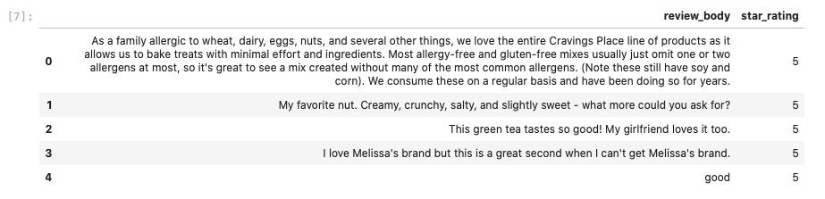

#### **2.3 Feature Engineering**

#### **2.3.1 Feature Engineering: Add New Column `sentiment` Based on `star_rating`**

We use `apply` method to apply a function to each row in the DataFrame by adding a new column `sentiment`. This will make it easier to visualize the data later.

```
def get_sentiment(value):
    if value > 3:
        return "positive"
    else:
        return "negative"
```

```
df['sentiment'] = df['star_rating'].apply(get_sentiment)
df.head()
```

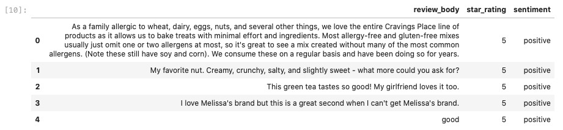

#### **2.3.2 Feature Engineering: Other Basic Cleaning Stuff**

First, after looking at the `unique` `star_rating` values, we notice that there are reviews with a `nan` rating.

[output not shown]

Second, in order to solve the problem, we remove those `nan` by using `drop_na` method.

```
df.dropna(inplace=True)
```

### 3. Data Visualization & Analysis

#### **3.1 Domain Knowledge and Data Schema**

#### **3.1.1 Domain Knowledge and Data Schema: Domain Knowledge**

(1) **Word cloud** is a visual representation of text data, typically used to depict keyword metadata (tags) on websites, or to visualize free form text. In word cloud representations the most frequent words in a document are graphically represented with larger sizes. With the help of word cloud, we could visualize our data and find the high-frequency words in the document.

(2) In this dataset, we use the "**star_rating**" column to reflect people's satisfaction, which has a scale of 1-5, with 1 as the lowest, 3 as neutral, and 5 has highest satisfaction level

#### **3.1.2 Domain Knowledge and Data Schema: Data Schema**

**Part 1:**

As we have already done in the data preparation process, we convert the star rating into two opposite groups in a new factor variable “sentiment”. We consider the rating of 1 star and 2 stars as negative comments while the rating of 4 stars and 5 stars as positive comments.

Here are all the variables we are dealing with in the whole dataset.

- **Review_body** (*string*): shows the content of the review for a certain product.
- **Star_rating** (*factor*): shows how much the customer likes a certain product.
- **Sentiment** (*factor*): shows the sentiment inclination based on the star rating results.

**Part 2:**

Later, since we need to conduct a deeper analysis of the data, we add more quantitative criteria (numeric variables) based on the content of the review body. This modification will contribute to the correlation test and regression analysis.

Here are all the other variables we are dealing with in the dataset besides the three above.

- **Num_words** (*number*): shows how many words there are in the review body part.
- **Num_unique_words** (*number*): shows how many unique words there are in the review body part.
- **Num_chars** (*number*): shows how many characters there are in the review body part.
- **Num_stopwords** (*number*): shows how many stopwords (i.e. “the”, “a/an”, “in”) there are in the review body part.
- **Num_punctuations** (*number*): shows how many punctuations there are in the review body part.
- **Mean_word_len** (*number*): shows the average length of the words in the review body part.

#### **3.2 Data Visualization**

#### **3.2.1 Data Visualization: Visualize the Review Counts**

We can visualize the counts to quickly see the breakout by `rate_rating` based on the data cleaning work we have done so far.

```
print(df['star_rating'].value_counts())
sns.countplot(x='star_rating', data=df)
```

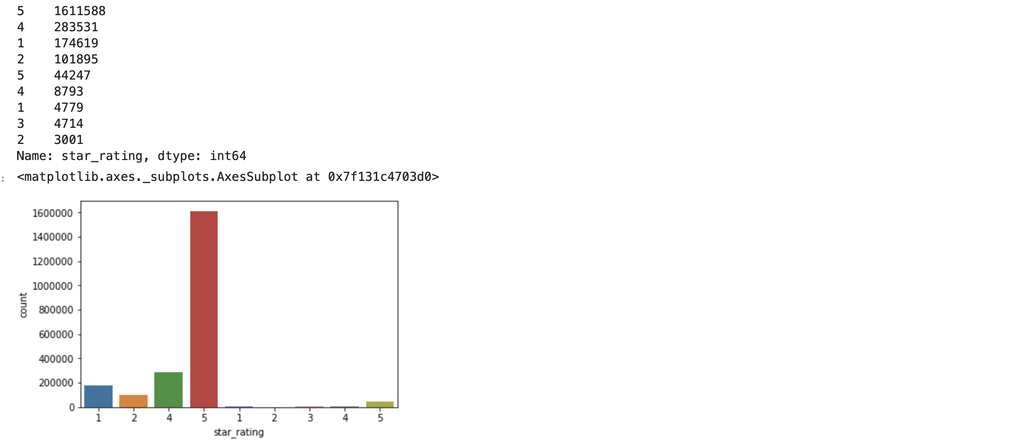

**Since in the above graph, we can tell that there are some duplicates in "star_rating", we need to do some cleasing of the data as below!**

#### **3.2.2 Data Visualization(Cleanse data): Visualize the Sentiment of the Reivews**

First, we de-deplicate the rows in order to get unbiased results. After checking duplicates based on `review_body` and `star_rating`, we will remove the records providing that all values are equal.

```
import string
df = df.drop_duplicates(subset={'review_body', 'star_rating'})
```

Second, we **transform** the `review_body` from its regular form, with capital letters to the pure lowercase text. We can also see below we have ratings with a nan value meaning no star_rating was giving for the review. We will drop the nan reviews as well to clean up the data set.

```
df.dropna(inplace=True)
df.loc[:, 'star_rating'] = df['star_rating'].astype(int)
df.loc[:, 'review_body'] = df['review_body'].astype(str).str.lower()
df.head()
```

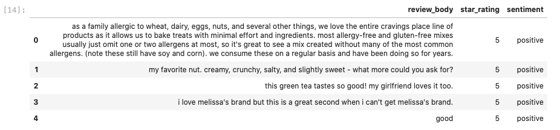

Third, we can visualize the counts to quickly see the distribution of positive reviews and negative reviews; and the cleased "star_rating" distributions:

```
print(df['sentiment'].value_counts())
sns.countplot(x='sentiment', data=df)
```

```
print(df['star_rating'].value_counts())
sns.countplot(x='star_rating', data=df)
```

[figure not shown]

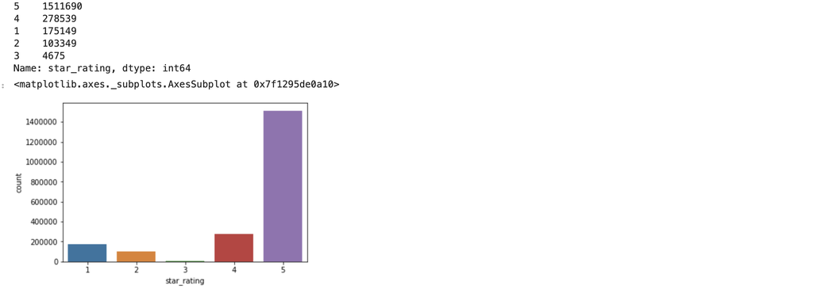

#### **3.2.3 Data Visualization: Python WordCloud Plot**

Since we would like to see what words stand out in the dataset, we use **WordCloud** visualization to accomplish goal.

First, we use `pip` t oinstall the library.

```
!python -m pip install wordcloud
from wordcloud import WordCloud, STOPWORDS
```

Second, we build a simple function `plot_wordcloud` to plot the words.

```
def plot_wordcloud(text, mask=None, max_words=150, max_font_size=150, figure_size=(25.0,15.0),
                   title = None, title_size=40, image_color=False):
    stopwords = set(STOPWORDS)

    wordcloud = WordCloud(background_color='black',
                    stopwords = stopwords,
                    max_words = max_words,
                    max_font_size = max_font_size,
                    random_state = 50,
                    width=800,
                    height=400,
                    mask = mask)
    wordcloud.generate(str(text))

    plt.figure(figsize=figure_size)
    if image_color:
        image_colors = ImageColorGenerator(mask);
        plt.imshow(wordcloud.recolor(color_func=image_colors), interpolation="bilinear");
        plt.title(title, fontdict={'size': title_size,
                                  'verticalalignment': 'bottom'})
    else:
        plt.imshow(wordcloud);
        plt.title(title, fontdict={'size': title_size, 'color': 'red',
                                  'verticalalignment': 'bottom'})
    plt.axis('off');
    plt.tight_layout()

plot_wordcloud(df['review_body'], title="Word Cloud Review_Comments of Amazon Reviews")
```

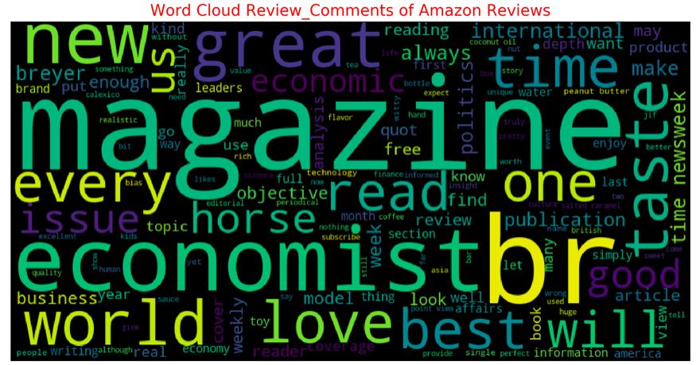

#### **3.3 Data Analysis**

#### **3.3.1 Data Analysis: Summary Statistics of `review_body`**

First, We use `string` package to explore more about `review_body`. We calculate the number of words in the text, the number of unique words in the text, the number of characters in the text, the number of stopwords in the text, the number of punctuations in the text, and the average length of the words in the text.

```
import string

## Number of words in the text ##
df["num_words"] = df["review_body"].apply(lambda x: len(str(x).split()))

## Number of unique words in the text ##
df["num_unique_words"] = df["review_body"].apply(lambda x: len(set(str(x).split())))

## Number of characters in the text ##
df["num_chars"] = df["review_body"].apply(lambda x: len(str(x)))

## Number of stopwords in the text ##
df["num_stopwords"] = df["review_body"].apply(lambda x: len([w for w in str(x).lower().split() if w in STOPWORDS]))

## Number of punctuations in the text ##
df["num_punctuations"] = df['review_body'].apply(lambda x: len([c for c in str(x) if c in string.punctuation]) )

## Average length of the words in the text ##
df["mean_word_len"] = df["review_body"].apply(lambda x: np.mean([len(w) for w in str(x).split()]))
```

Second, we use `describe` function to show the summary of statistics of those variables.

```
df.describe()
```

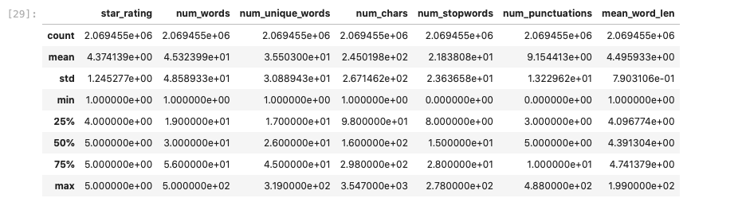

#### **3.3.2 Data Analysis: Correlation between `star_rating` and `num_word`**

We would like to explore that whether the rating reviews that have more number of words will result in a negative star rating outcome. But surprisingly, we only find that the correlation coefficient is -0.0856. (Since we believe longer review comments tend to be more negative, since those customers have more to complain about)

[output not shown]

#### **3.3.3 Data Analysis: Simple Regression Model of `star_rating` and `num_word`**

Although there is only a weak correlation between the star rating and number of word, we still would like to explore whether there is a linear relationship. But the result shows a correspondence with the result of correlation coefficient: they do not have a strong linear relationship since the **adjusted R-square** is only 0.007, which is too low to reflect a strong linear relationship between star_rating and num_word

```
import statsmodels.api as sm
import statsmodels.formula.api as smf

# print the summary of the results
results = smf.ols('star_rating ~ num_words', data=df).fit()
print(results.summary())
```

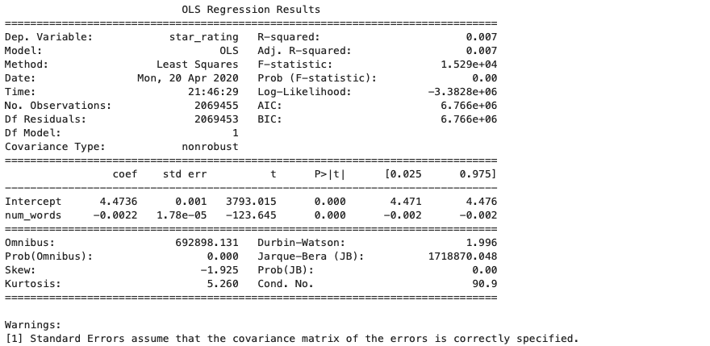

### 4. Productionization & Deployment

#### **4.1 Upload Notebook and .yaml file to Github**

1. Go to [GitHub.com](https://github.com), and create a new repository as “[qtm350-capstone](https://github.com/wwan210/qtm350-capstone.git)”;
2. Download QTM350_capstone.ipynb (our jupyter notebook done on SageMaker where you can edit the code) and upload to “qtm350-capstone";
3. Upload “amazon-review.yaml” (where you can access to the information of reviews dataset and .tsv file of the data we use) to “qtm350-capstone”

#### **4.2 Make the notebook Available as a Web Page**

Now we are going to demonstrate how we made our notebook available as a web page.

#### **4.2.1: Convert an `ipynb` file into a local `html` file**

1. Log into AWS **SageMaker** service;
2. Go to Notebook Instance, and open JupyterLab;
3. Open a terminal, and write `cd SageMaker`;
4. Once in SageMaker directory, upload `QTM350_capstone.ipynb` to JupyterLab, by clicking on the icon shown below;
5. Then, in the terminal, write `jupyter nbconvert QTM350_captsone.ipynb` in the terminal;
6. Download `QTM350_captsone.html` to a local file folder.

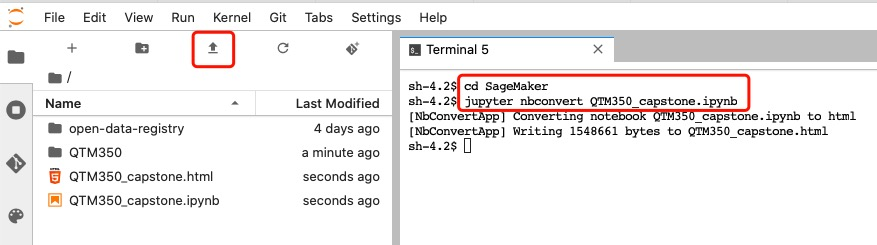

#### **4.2.2 Convert the local `html` file into public**

1. Go to AWS **S3** service;
2. Go to one of the buckets whose access is shown that `Objects can be public`.
3. Upload `QTM350_captsone.html`;
4. Go to `Properties` and under which, click `Static website hosting`, paste the html file name into `Index document`, and Save;
5. Go back to `Overview`, and click on our html file `QTM350_captsone.html`;
6. The listed Object URL is the link to the public web page.

[figure not shown]

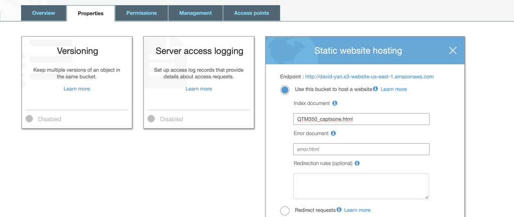

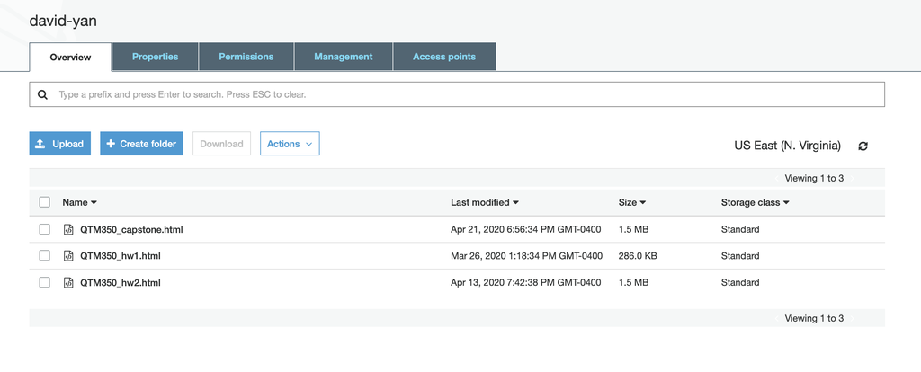

#### **4.3 Improve the Process by Automatic Updates with Lambda**

#### **4.3.1 What are lambda functions?**

AWS Lambda is a serverless compute service that lets you run code without provisioning or managing servers. AWS Lambda executes your code only when needed and scales automatically, from a few requests per day to thousands per second.

There are 3 types of methods by which you can deploy your code on AWS Lambda.

- Using in-line editor and working with libraries only available in Lambda. (up to 3 MB)
- Making a zipped deployment package and uploading it via Lambda console. (up to 50 MB)
- Making a zipped package and saving it in the S3 bucket. (up to 250 MB when unzipped)

#### **4.3.2 Why are we doing automatic updates with lambda?**

If we make the Lambda function using a zip file present on S3, the code is not updated if we make any changes in the zip file. For the Lambda to get updated, we have to go to the console and update it manually.

#### **4.3.3 How are we going to achieve this?**

*We will be using AWS Developer Tools and an intermediate Lambda function.*

- **Create S3 Bucket** — Create an S3 bucket that will store your zip file for lambda.
- **Create Lambda Functions** — Create 2 lambdas. The main function ( say targetLambda) can be created using your desired environment and the intermediate one (say intermediateLambda) we will create using NodeJs environment. Let the targetLambda be empty for now. The intermediateLambda’s code would look like the following:

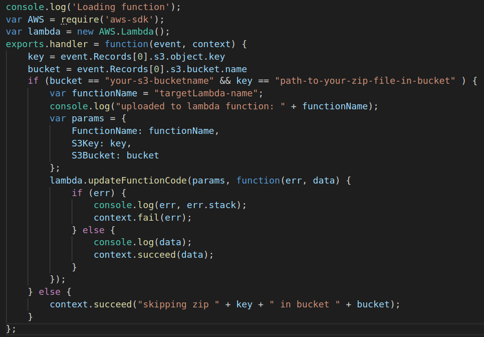

Lets now add an S3 trigger to intermediateLambda so that whenever there is any change in zip file present in the bucket this function is called.

- **Create CodeBuild** — The first step is to tell CodeBuild which repo and branch to use to create the zip file and make a Buildspec file. We will edit the Buildspec file in the console and make changes in build and artifacts. Run this step and ensure that your zipped file is pushed to your desired destination in the S3.

```
build:
commands:
— cd ./deploymentDir
— zip -r deployment.zip *
— aws s3 cp deployment.zip s3://your-bucketname/location-of-zip
artifacts:
files:
— ./deploymentDir/deployment.zip
```

- **Create Codepipeline** — We will skip CodeDeploy step and jump straight into Codepipeline where we describe when to run the CodeBuild step. Here we tell our source-name and build-project-name.

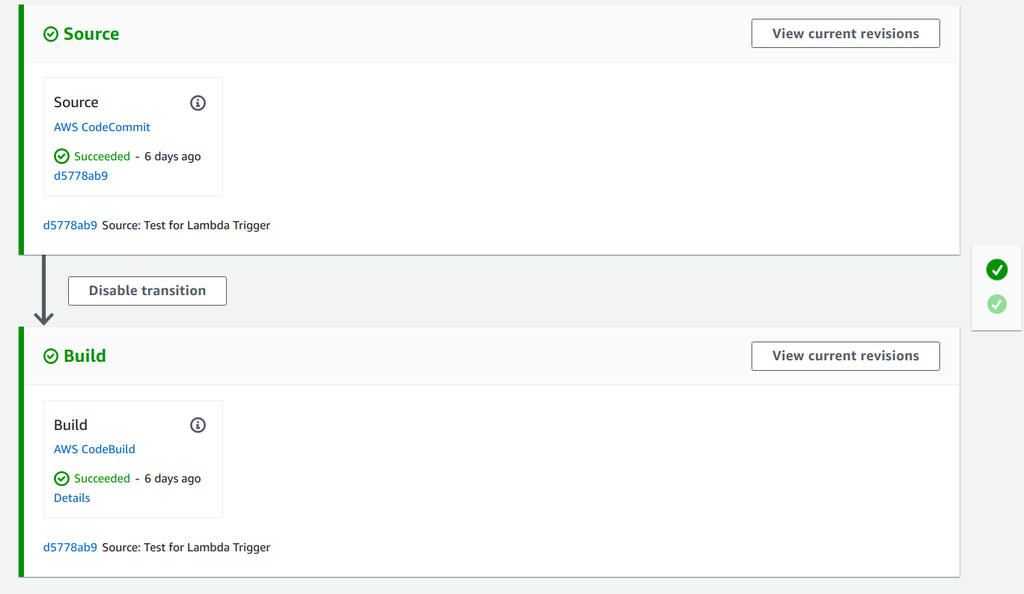

### 5. Domain-Specific Goal Evaluation & Prediction

#### **5.1 Evaluation**

As we mentioned in our problem framing, buying groceries on e-commerce platforms like Amazon fresh is getting to be increasingly popular, and due to the corona virus outbreak, we believe it will still last for at least a couple of months, and it motivates us to evaluate the data and information on customer reviews on grocery section of Amazon. As we predicted, customer reviews play a significant role in the online grocery market, and we would like to analyze data that we have to investigate whether our prediction is right.

Moreover, we use WordCloud to visualize the keywords in customer reviews, and show them together in one picture and present them the size according to their appearance frequency, and from the result, we can surprisingly find that magazine is the most frequent word in the review, along with, love, best, great, time, and so on. We can find positive words are dominant, so that we can also find that positive reviews are more than negative reviews.

Even though we only apply our analysis in the grocery section of Amazon reviews, we can in fact apply it into different categories in different sections, and since ols regression model is one of the most popular analysis tools currently, we can in fact run ols regression model with any two numeric variables. Therefore, we believe our analysis has a wide-range of applications.

#### **5.2 Prediction**

The method we use to test the popularity of Amazon grocery reviews could also be used in different ways. Our analysis could be further designed as an online application, which could analyze customer’s reviews from different merchant platforms. For instance, the other e-commerce platforms could see the visualization of satisfactory level of customers. Moreover, using sentiment analysis and wordcloud, merchants could know more about customer’s feedback. The key words of consumers would definitely help merchants to distribute their goods and adapt the market. In addition, the OLS models could check the relationship between different variables.

Customers are able to get a deeper understanding of the market by using our application as well. Though it is hard for customers to gather all the information, it is viable that most e-commerce platforms provide all of the customers’ reviews. To test our methods, we invited our friends in China to check if our code could provide information based on the dataset. They collected data from Pinduoduo, one of the largest e-commerce platforms in China, to test people’s reviews of the electronic products. The result shows that the high-frequency words are low-quality, fake and cheap. The sentiment analysis also shows the low rating of satisfactory level. The result is consistent with reality that Pinduoduo is not a platform with a good reputation, and the key words point out the problems that the goods from Pinduoduo are mostly fake with low quality. The testing is successful, but we encounter a problem of data collecting. Our friends spend hours collecting data from the reviews of the platform. It is impossible for future users to collect data by themselves, so the web scraping function is expected to add to our application to make users easier to get the results.

### 6. AI Service: Rekognition

AWS AI services provide vision, transcription, translation, personalization, and forecasting capabilities without the need for training and deploying machine learning models. AWS manages the machine learning complexity, we just focus on the problem at hand and send required inputs for analysis and receive output from these services within our applications.

We will start by importing dependencies for AWS SDK, Python Data Frames, file operations, handling JSON data, and display formatting. We will initialize the Rekognition client for use in the rest of this notebook.

```
import boto3
import pandas as pd
import io
import json
from IPython.display import display, Markdown, Image

rekognition = boto3.client('rekognition','us-east-1')
image_bucket = 'open-data-analytics-grocery'
```

#### **6.1 Show Image**

We will work with an image so we need a way to show the image within this notebook. Our function creates a public image URL based on S3 bucket and key as input.

```
def show_image(bucket, key, img_width = 500):
    # [TODO] Load non-public images
    return Image(url='https://cdn.geekwire.com/wp-content/uploads/2020/' + bucket + '/' + key, width=img_width)
```

```
show_image(image_bucket, 'grocery.png', 1024)
```

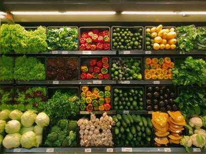

#### **6.2 Image Label**

First step in this kind of analytics is to recognize that we are actually looking at an image which may represent a grocery store). We create `image_labels` function which uses `detect_lables` Rekognition API to detect objects within an image. The function prints labels detected with confidence score.

```
def image_labels(bucket, key):
    image_object = {'S3Object':{'Bucket': bucket,'Name': key}}

    response = rekognition.detect_labels(Image=image_object)
    for label in response['Labels']:
        print('{} ({:.0f}%)'.format(label['Name'], label['Confidence']))
```

[output not shown]